# Lab 7 Key

## Lab 7: Two-Way Within-Subjects ANOVA

### Background

Eight adults are asked to learn several sets of vocabulary words within each of three time periods: 30 seconds, 60 seconds, and 180 seconds. They experienced each time period twice with differing directions for each occurrence; they were told to study by memorizing the words and then they were told to study using story and image mnemonics. A vocabulary test for the target set of words studied in a condition followed each study period.

### Restructure Data

To get the data in a format that is better to work with, `rename()` variables and then use `pivot_longer()` to get data in a format R can use.

```r
needs(tidyverse, rio, here, knitr, kableExtra, misty, janitor, rstatix, psych, misty, MOTE)

lab7_data_raw <- misty::read.sav(here("assignments_data", "Lab7_Rutherford.sav"), use.value.labels = TRUE)

head(lab7_data_raw) #what it looks like before
```

```
##   ID A1B1 A1B2 A1B3 A2B1 A2B2 A2B3
## 1  1    7    7    8   16   16   24
## 2  2    3   11   14    7   10   29
## 3  3    6    9   10   11   13   10
## 4  4    6   11   11    9   10   22
## 5  5    5   10   12   10   10   25
## 6  6    8   10   10   11   14   28
```

```r
lab7_data_pivot <- lab7_data_raw %>%
  rename(mem_30 = A1B1,
         mem_60 = A1B2,
         mem_180 = A1B3,
         mne_30 = A2B1,
         mne_60 = A2B2,
         mne_180 = A2B3) %>%
  pivot_longer(cols = -ID, values_to = "total", names_to = "condition")

lab7_data <- lab7_data_pivot %>%
  separate(condition, into = c("condition", "study_time"), sep = "_")

head(lab7_data) #what it looks like when it's clean
```

```
## # A tibble: 6 × 4
##      ID condition study_time total
##   <dbl> <chr>     <chr>      <dbl>
## 1     1 mem       30             7
## 2     1 mem       60             7
## 3     1 mem       180            8
## 4     1 mne       30            16
## 5     1 mne       60            16
## 6     1 mne       180           24
```

### Descriptions & Assumptions

```r
str(lab7_data)
```

```
## tibble [48 × 4] (S3: tbl_df/tbl/data.frame)
##  $ ID        : num [1:48] 1 1 1 1 1 1 2 2 2 2 ...
##  $ condition : chr [1:48] "mem" "mem" "mem" "mne" ...
##  $ study_time: chr [1:48] "30" "60" "180" "30" ...
##  $ total     : num [1:48] 7 7 8 16 16 24 3 11 14 7 ...
```

```r
factor_cols <- c("ID", "condition", "study_time")
lab7_data[factor_cols] <- lapply(lab7_data[factor_cols], as.factor)

str(lab7_data)
```

```
## tibble [48 × 4] (S3: tbl_df/tbl/data.frame)
##  $ ID        : Factor w/ 8 levels "1","2","3","4",..: 1 1 1 1 1 1 2 2 2 2 ...
##  $ condition : Factor w/ 2 levels "mem","mne": 1 1 1 2 2 2 1 1 1 2 ...
##  $ study_time: Factor w/ 3 levels "180","30","60": 2 3 1 2 3 1 2 3 1 2 ...
##  $ total     : num [1:48] 7 7 8 16 16 24 3 11 14 7 ...
```

```r
lab7_data$study_time <- ordered(lab7_data$study_time, levels = c("30", "60", "180")) #reorder levels
```

```r
describe(lab7_data)
```

```
##             vars  n mean   sd median trimmed  mad min max range skew kurtosis
## ID*            1 48  4.5 2.32    4.5    4.50 2.97   1   8     7 0.00    -1.31
## condition*     2 48  1.5 0.51    1.5    1.50 0.74   1   2     1 0.00    -2.04
## study_time*    3 48  2.0 0.83    2.0    2.00 1.48   1   3     2 0.00    -1.56
## total          4 48 12.0 6.03   10.5   11.25 3.71   3  29    26 1.35     1.04
##               se
## ID*         0.33
## condition*  0.07
## study_time* 0.12
## total       0.87
```

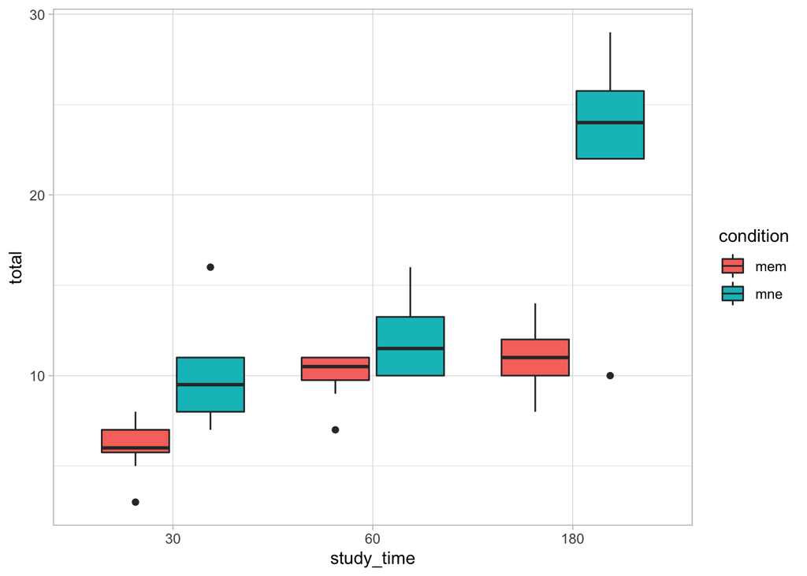

```r
ggplot(lab7_data, aes(x = study_time, y = total, fill = condition)) +
  geom_boxplot() +
  theme_light()
```

Overall, the mnemonics conditions have higher scores than their memorize counterparts, for each study time. As study time increases, the scores also seem to generally increase. Mnemonics at the 180 second condition appears to be well above any of the other conditions and times.

*Assumptions:*  
* Average vocabulary score across all participants and conditions is 12 (sd = 6.03) and is approximately normally distributed (skew and kurtosis < ±2).  
* We assume that the inclusion of one participant does not affect the inclusion of another. Participant participation is independent of one another.  
* Sphericity assumption holds for the condition and study time interaction (p = .053) according to Mauchly’s test below.

### Two-way within-subjects ANOVA

```r
m1 <- afex::aov_car(total ~ condition + study_time + condition:study_time + Error(ID/condition*study_time),
                           data=lab7_data, include_aov = F)
summary(m1)
```

```
##
## Univariate Type III Repeated-Measures ANOVA Assuming Sphericity
##
##                      Sum Sq num Df Error SS den Df F value    Pr(>F)
## (Intercept)            6912      1   52.000      7 930.462 1.050e-08 ***
## condition               432      1   75.333      7  40.142 0.0003905 ***
## study_time              672      2  161.000     14  29.217 1.008e-05 ***
## condition:study_time    224      2   91.667     14  17.105 0.0001741 ***
## ---
## Signif. codes:  0 '***' 0.001 '**' 0.01 '*' 0.05 '.' 0.1 ' ' 1
##
##
## Mauchly Tests for Sphericity
##
##                      Test statistic  p-value
## study_time                  0.23876 0.013612
## condition:study_time        0.37730 0.053709
##
##
## Greenhouse-Geisser and Huynh-Feldt Corrections
##  for Departure from Sphericity
##
##                       GG eps Pr(>F[GG])
## study_time           0.56778  0.0005333 ***
## condition:study_time 0.61626  0.0020461 **
## ---
## Signif. codes:  0 '***' 0.001 '**' 0.01 '*' 0.05 '.' 0.1 ' ' 1
##
##                        HF eps   Pr(>F[HF])
## study_time           0.604025 0.0003809442
## condition:study_time 0.681413 0.0013411407
```

```r
effectsize::omega_squared(m1)
```

```
## # Effect Size for ANOVA (Type III)
##
## Parameter            | Omega2 (partial) |       95% CI
## ------------------------------------------------------
## condition            |             0.74 | [0.33, 1.00]
## study_time           |             0.73 | [0.45, 1.00]
## condition:study_time |             0.56 | [0.20, 1.00]
##
## - One-sided CIs: upper bound fixed at (1).
```

ANOVA results indicate a significant interaction between condition and study time (*F*(2, 14) = 17.105, *p* < .001, $\omega^2_p$ = 0.56), where the differences between condition and study time groups jointly explain about 56% of the variances among vocabulary learning scores.

The means for each condition are visualized below, first by study time and then by condition.

*Plot Marginal Means*

```r
means <- lab7_data %>%
  group_by(condition, study_time) %>%
  summarise(total = mean(total)) %>%
  mutate(study_time = factor(study_time, c("30", "60", "180")))
```

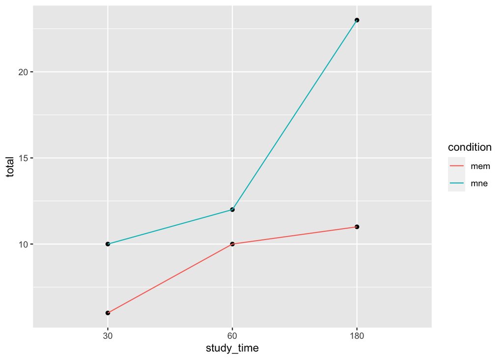

```r
ggplot(means, aes(x = study_time, y = total, group = condition)) +
  geom_point() +
  geom_line(aes(color = condition))
```

As study time increased, vocabulary scored increased. The non-parallel lines indicate study time interaction with condition.

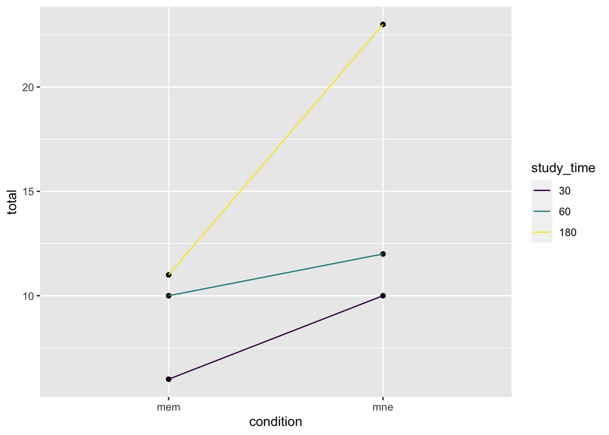

```r
ggplot(means, aes(x = condition, y = total, group = study_time)) +
  geom_point() +
  geom_line(aes(color = study_time))
```

For all cases, mnemonics were associated with higher vocabulary scores than the memorize conditions.

### Pairwise Comparisons

```r
needs(emmeans)
em <- emmeans(m1, ~study_time*condition)
pairs(em)
```

```
##  contrast            estimate    SE df t.ratio p.value
##  X30 mem - X60 mem         -4 0.845  7  -4.733  0.0168
##  X30 mem - X180 mem        -5 1.086  7  -4.606  0.0194
##  X30 mem - X30 mne         -4 0.866  7  -4.619  0.0191
##  X30 mem - X60 mne         -6 0.567  7 -10.583  0.0001
##  X30 mem - X180 mne       -17 2.196  7  -7.742  0.0010
##  X60 mem - X180 mem        -1 0.378  7  -2.646  0.2024
##  X60 mem - X30 mne          0 1.488  7   0.000  1.0000
##  X60 mem - X60 mne         -2 1.225  7  -1.633  0.6052
##  X60 mem - X180 mne       -13 1.991  7  -6.529  0.0027
##  X180 mem - X30 mne         1 1.581  7   0.632  0.9844
##  X180 mem - X60 mne        -1 1.350  7  -0.741  0.9696
##  X180 mem - X180 mne      -12 1.927  7  -6.226  0.0036
##  X30 mne - X60 mne         -2 0.535  7  -3.742  0.0530
##  X30 mne - X180 mne       -13 2.435  7  -5.339  0.0088
##  X60 mne - X180 mne       -11 2.299  7  -4.785  0.0159
##
## P value adjustment: tukey method for comparing a family of 6 estimates
```

### Contrasts: post-hoc

“To what extent does the effect of study time on vocabulary learning depend on study method instructions for adults?” From the graphed data in the boxplot, it looks like the difference time makes (specifically from 60 to 180 seconds) may differ as a function of instruction method. Therefore, I tested this difference using a custom contrast.

```r
em #first just look at order of factors to specify coding
```

```
##  study_time condition emmean    SE df lower.CL upper.CL
##  X30        mem            6 0.535  7     4.74     7.26
##  X60        mem           10 0.500  7     8.82    11.18
##  X180       mem           11 0.627  7     9.52    12.48
##  X30        mne           10 1.000  7     7.64    12.36
##  X60        mne           12 0.779  7    10.16    13.84
##  X180       mne           23 2.062  7    18.13    27.87
##
## Confidence level used: 0.95
```

```r
contrasts <- list(
  hyp1 = c(0, 1, -1, 0, -1, 1)
)
contrast(em, contrasts)
```

```
##  contrast estimate  SE df t.ratio p.value
##  hyp1           10 2.2  7   4.537  0.0027
```

```r
#Calculate effect size with Omega
# First turn t-ratio into F-ratio by squaring it: t^2 = F
# (4.537)^2
# Fvalue = 20.58437

# Second, put in values accordingly:
omega.F(dfm = 1, dfe = 7,
      Fvalue = 20.58437, n = 48, a = .005)
```

```
## $omega
## [1] 0.2897766
##
## $omegalow
## [1] 0
##
## $omegahigh
## [1] 0.8513177
##
## $dfm
## [1] 1
##
## $dfe
## [1] 7
##
## $F
## [1] 20.58437
##
## $p
## [1] 0.002677255
##
## $estimate
## [1] "$\\omega^2$ = 0.29, 99.5\\% CI [0.00, 0.85]"
##
## $statistic
## [1] "$F$(1, 7) = 20.58, $p$ = .003"
```